# Conway_Emily_final_project

Emily Conway

2023-12-12

#### Step #1: Set global options and load packages

#### Step #2: Import water use data; clean data

**Q1: What data are you using?** The first data set used in this project is an xlsx file entitled [“Conservation Practices Applied by Conservation Program and Fiscal Year”](https://www.nrcs.usda.gov/rca-data-downloads) which is a Conservation Practice Summary for the United States’ Soil and Water Resource Conservation Act (RCA). This data set includes information on the RCA program, conservation practice name, and acreage of soil and water conservation practices applied in each state and year. Specifically, this data set contains data for different conservation irrigation system types throughout the United States from 2005-2022.

The second data set is a csv zip file entitled [“2018 Irrigation and Water Management Survey”](https://www.nass.usda.gov/Publications/AgCensus/2017/Online_Resources/Farm_and_Ranch_Irrigation_Survey/index.php) which includes many tables of data on the irrigation of agricultural lands across the United States relative to 2018. Specifically, the two csv files for Table 2 and 31 will be used from this zip file: Table 2: Irrigated Farms by Acres Irrigated (fris_p015_t0002.csv) which contains data on the total irrigated acreage by state in 2013 and 2018. Table 31: Drip, Trickle, or Low-Flow Micro Irrigation in Fields in the Open: 2018 and 2013 (fris_p115_t0102.csv) which contains irrigated acreage of conservation irrigation practices in 2013 and 2018. These conservation practices include surface drip, sub-surface drip, low-flow micro sprinklers, and other drip, trickle, or low-flow micro systems.

**Q2: Where are the data from?** These two data sets are from the United States Department of Agriculture (USDA). The first data set ([Conservation Practice Summary](https://www.nrcs.usda.gov/rca-data-downloads)) is found on the USDA’s Natural Resource Conservation Service (NRCS) under the RCA Data Downloads. The second data set ([2018 Irrigation and Water Management Survey](https://www.nass.usda.gov/Publications/AgCensus/2017/Online_Resources/Farm_and_Ranch_Irrigation_Survey/index.php)) is from the USDA’s National Agricultural Statistics Service.

Figure 2 will be a map that colors each U.S. state to represent the leading type of conservation irrigation for each state. This map will be plotted using geom_sf() with the CRS code 5070 (best coordinate reference system analyzing the lower 48 U.S. states) and labeled with geom_sf_label(). This will visually represent the spatial distribution of leading conservation irrigation types in 2018.

**Q5: What is the main point of each of your figures?** Figure 1 will show the trends in acreage irrigated by the four described conservation systems in California over time from RCA programs as well as the acreage values of each conservation irrigation system. Figure 2 will create color coded map that shows the leading sectors of conservation irrigation each U.S. state in 2018. Figure 3 will create a visual comparison of the total acreage of conservation irrigation for the top 10 irrigated states in the U.S. in 2018. These figures will reveal trends in how conservation irrigation acreages, by system type and totals, have changed over time and location in the United States.

**Q6: Why did you choose the data that you chose? Why did you choose the topic that you choose?** I chose these two data sets because they are from a reputable source (USDA), are readable (xslx and csv with little NA values), and address agricultural water uses that I am interested in. I originally wanted to research soil water in agriculture, but there was more accessible data on irrigated agricultral lands. These data sets are readily available as tables in csv and xlsx files that contain state totals which are much easier to plot than the soil moisture data in the form of geospatial rasters. Since the RCA data regards conservation practices for both water and soil in U.S. agriculture, it combines my environmental interests of agriculture, soil, and water.

**Q7: In what ways are you hoping this project challenges you?** This project will challenge me to wrangle a large data set and join it with a smaller one of a different file type. Since the xlsx data set is large, I will have to manipulate the tables using several functions to organize the specific data I need for the plots. I am hoping this project challenges me to think critically and ask more questions that can be answered with the data as well as improve my data collection and wrangling skills. I am also hoping to be challenged in my scientific communication skills by creating clear data visualizations and plot descriptions that help to answer and communicate my research questions to the general public.

```r
# Conservation Practice Summary for the Soil and Water Resource Conservation Act (2005-2022), from USDA
irrigation <- read_xlsx(here("data/rca_practices.xlsx"), sheet = 5, skip = 2) |> # import xlsx file, read sheet 5, skip 2 lines
              clean_names()                                                      # clean names to snake_case

# Table 2 from 2018 Irrigation and Water Management Survey: Irrigated Farms by Acres Irrigated (2013 & 2018), from USDA
state_acres <- read_csv(here("data/irrigated_2013_2018.csv"), skip = 3) |>       # import csv file, skip 3 lines
               clean_names()                                                     # clean names to snake_case
```

```
## ──────────────────────────────────────────────────────── Delimiter: "," chr
## (14): h, ...3, ...5, ...6, ...7, ...8, ...9, ...10, ...11, ...12, ...13,... dbl
## (2): 2, ...4
```

```r
# Table 31 from 2018 Irrigation and Water Management Survey: Drip, Trickle, or Low-Flow Micro Irrigation in Fields in the Open: 2018 and 2013, from USDA
conservation <- read_csv(here("data/conservation_ir.csv"), skip = 5) |>          # import csv file, skip 5 lines
                clean_names()                                                    # clean names to snake_case
```

```
## ──────────────────────────────────────────────────────── Delimiter: "," chr
## (12): h, ...3, ...5, ...6, Surface drip...7, Surface drip...8, Sub-surfa... dbl
## (2): 102, ...4
```

```r
# Coordinates for the center of each state in the United States, RDS from Canvas page
centroids <- readRDS(here("data/state_centroids.rds"))                           # import RDS file, already in snake_case

# Boundaries of each state in the United States in 2018 (MULTIPOLYGON), from US Census Bureau
state_boundaries <- st_read(here("data/cb_2018_us_state_20m.shp")) |>            # import shapefile
                    clean_names()                                                # clean names to snake_case
```

#### Step #3: Organize data for Plot 1: Acres of conservation irrigation and irrigation water management installed annually in California from 2005-2022

```r
# create data frame: acreage of each conservation irrigation system added in CA in the years 2005-2022
ca_conserv <- irrigation |>                                                      # data from irrigation data frame
            select(state_name, practice_name, 7:42) |>                           # select columns of interest
            filter(practice_name %in% c("Irrigation System, Microirrigation", "Irrigation System, Sprinkler", "Irrigation System, Surface and Subsurface", "Irrigation System, Tailwater Recovery")) |>  # filter for conservation irrigation systems practices
            filter(state_name %in% "California") |>                              # filter for the state of California
            mutate_at(c(3:38), as.numeric, na.rm = TRUE) |>                      # coerce columns 3-38 to numeric, don't include NA values in statistics
            group_by(practice_name) |>                                           # group by practice name
            summarize_at(2:37, sum, na.rm = TRUE) |>                             # sum columns 2-37, don't include NA values in statistics
            ungroup() |>                                                         # ungroup
            select(!contains("count")) |>                                        # select columns that don't include the string "count"
            select(system = practice_name, "2005" = x2005_acres, "2006" = x2006_acres, "2007" = x2007_acres, "2008" = x2008_acres, "2009" = x2009_acres, "2010" = x2010_acres, # clean column names with select
                   "2011" = x2011_acres, "2012" = x2012_acres, "2013" = x2013_acres, "2014" = x2014_acres, "2015" = x2015_acres, "2016" = x2016_acres, "2017" = x2017_acres,   # clean column names with select
                   "2018" = x2018_acres, "2019" = x2019_acres, "2020" = x2020_acres, "2021" = x2021_acres, "2022" = x2022_acres) |>                                            # clean column names with select
           pivot_longer(cols = 2:19,                                             # pivot columns 2-19 longer
                         names_to = "year",                                      # column names to new year column
                         values_to = "withdrawals")                              # values to new withdrawals column

# create data frame: acreage of Irrigation Water Management added in CA in the years 2005-2022
managed <- irrigation |>                                                         # data from irrigation data frame
            select(state_name, practice_name, 7:42) |>                           # select columns of interest
            filter(practice_name %in% c("Irrigation Water Management")) |>       # filter for rows with the Irrigation Water Management practice
            filter(state_name %in% "California") |>                              # filter for rows for the state of California
            mutate_at(c(3:38), as.numeric, na.rm = TRUE) |>                      # coerce columns 3-38 to numeric, don't include NA values in statistics
            group_by(practice_name) |>                                           # group by practice name
            summarize_at(2:37, sum, na.rm = TRUE) |>                             # take the sum of columns 2-37, don't include NA values in statistics
            ungroup() |>                                                         # ungroup
            select(!contains("count")) |>                                        # select all columns that do not contain the string "count"
            select(system = practice_name, "2005" = x2005_acres, "2006" = x2006_acres, "2007" = x2007_acres, "2008" = x2008_acres, "2009" = x2009_acres, "2010" = x2010_acres, # clean column names with select
                   "2011" = x2011_acres, "2012" = x2012_acres, "2013" = x2013_acres, "2014" = x2014_acres, "2015" = x2015_acres, "2016" = x2016_acres, "2017" = x2017_acres,   # clean column names with select
                   "2018" = x2018_acres, "2019" = x2019_acres, "2020" = x2020_acres, "2021" = x2021_acres, "2022" = x2022_acres) |>                                            # clean column names with select
           pivot_longer(cols = 2:19,                                             # pivot columns 2-19 longer
                         names_to = "year",                                      # column names to new year column
                         values_to = "withdrawals")                              # values to new withdrawal column
```

#### Step #4: Plot 1: Acres of conservation irrigation and irrigation water management installed annually in California from 2005-2022

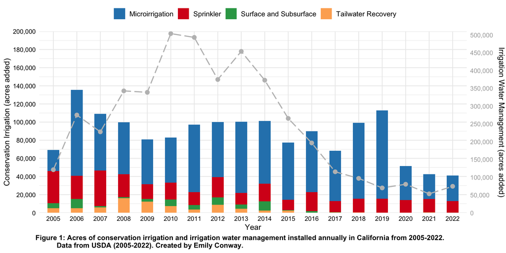

```r
ggplot() +                                                                       # create ggplot
  geom_col(data = ca_conserv,                                                    # create columns, data from ca_conserv df
           aes(x = year, y = withdrawals, fill = system),                        # set x & y axis data, fill each column with system (irrigation type)
           position = "stack", width = 0.5) +                                    # stacked columns, set width of columns
  geom_line(data = managed,                                                      # create line, data from managed df
            aes(x = year, y = (withdrawals / 2.55), group = 1),                  # set x & y data, divide y by 2.55 to match transformation of secondary y axis values, group = 1 to fix error
            color = "grey", linetype = "longdash", size = 0.75) +                # set line color & size
  geom_point(data = managed,                                                     # create points to add markers for each year we have annual conservation irrigation acreage data
             aes(x = year, y = withdrawals / 2.55) ,                             # assign x & y axis data, divide y by 2.55 to match transformation of secondary y axis values
             color = "grey", fill = "grey", size = 2.5) +                        # set color & size of points
  labs(x = "Year", y = "Conservation Irrigation (acres added)",                  # set x & y axis labels
       caption = "Figure 1: Acres of conservation irrigation and irrigation water management installed annually in California from 2005-2022.
                            Data from USDA (2005-2022). Created by Emily Conway.", # set plot caption
       fill = "") +                                                              # fill to remove legend title
  theme_minimal() +                                                              # set plot theme
  theme(legend.position = "top",                                                 # move legend to top
        plot.caption = element_text(hjust = -0.2, color = "black", face = "bold", size = 10), # format plot caption (adjust horizontally, color, bold, size)
        legend.text = element_text(color = "black", size = 10),                  # legend text settings
        axis.text.x = element_text(color = "black", size = 9),                   # x axis value text settings
        axis.title.x = element_text(color = "black", size = 11),                 # x axis title settings
        axis.text.y = element_text(color = "black", size = 9),                   # y axis value text settings
        axis.title.y = element_text(color = "black", size = 11),                 # y axis title settings
        axis.text.y.right = element_text(color = "darkgrey", size = 9),             # format second y axis values
        axis.title.y.right = element_text( vjust = 2.5, color = "black", size = 11)) + # format second y axis label (vertically adjust to reduce crowding)
  scale_fill_manual(labels = c("Microirrigation", "Sprinkler", "Surface and Subsurface", "Tailwater Recovery"), # change legend label names
                    values = c("#2b83ba", "#d7191c", "#31a354", "#fdae61", "#bababa")) + # assign colors to each sector
                    # change order of sectors
 #scale_x_continuous(expand = (c(0,0)))
  scale_y_continuous(sec.axis = sec_axis(trans = ~.*2.55,                        # create secondary axis, transform to fit scale (transformation of left axis values by factor of 2.55)
                                         name = "Irrigation Water Management (acres added)", # set secondary axis name
                                         breaks = scales::pretty_breaks(n = 10), # set pretty breaks for secondary axis
                                         labels = scales::comma),                # separate secondary axis markers with commas (ex. 1,000,000 rather than 1000000)
                     breaks = scales::breaks_extended(n = 10),                     # set pretty breaks for y axis
                     labels = scales::comma,                                     # separate axis value labels with commas
                     limits = c(0, 200000),                                      # set limits of y axis (range from 0-200,000)
                     expand = c(0, 0))                                           # expand y axis to close gaps
```

**Q2: What is most (or least) surprising?** It is surprising that the total amount of conservation irrigation acreage decreased overall from the years 2015-2022. It would be expected that the installation of conservation irrigation would increase in more recent years due to increased drought and technological advancements. However, this trend may be explained by the changes in presidential office in 2016, which had led to large budget cuts to environmental programs.

**Q3: What five new functions did you implement to support visualization of the data? Explain what each of them does** theme_minimal() - This function sets the theme of the plot to be minimalistic with no background annotations. This theme works well with this graph since there is a lot of information being displayed. breaks_extended() - This function is an extended breaks algorithm for numerical axes which allowed me to set the breaks in y axis values.

#### Step #5: Organize data for Plot 2: Leading conservation irrigation system by state in the U.S. in 2018

```r
# create df for state boundaries of U.S. states for map visualization
conus <- state_boundaries |>                                                     # data from state_boundaries
         filter(!stusps %in% c("AK", "HI", "PR")) |>                             # remove Alaska, Hawaii, and Puerto Rico
         st_transform(5070) |>                                                   # define CRS as 5070, best for analysis on contiguous lower 48 states
         select(state = name, postal = stusps)                                   # select columns of interest and rename columns

# create df for state centroids for U.S. map visualization
centroids_spatial <- centroids |>                                                # data from centroids
                     st_as_sf(coords = c("lng", "lat"), crs = 5070)              # convert foreign object (coordinates) to sf object, CRS as 5070

# create df for the total acreage of conservation irrigation for each state in 2018
total_conserv <- conservation |>                                                 # data from conservation
                 select(state = x3, total = x6, surface_drip = surface_drip_8, sub_drip = sub_surface_drip_10, micro_sprinkler = micro_sprinklers_12, low_flow_micro = low_flow_micro_systems_14) |> # select and rename conservation irrigation columns
                 mutate_at(2:6, as.numeric, na.rm = TRUE) |>                     # coerce columns 2-6 to numeric, don't include NA values in statistics
                 filter(!state %in% NA) |>                                       # remove rows with state NA values
                 filter(!state %in% c("Geographic area", "United States", "2018 DATA", "Hawaii")) |> # remove rows
                 slice(1:49) |>                                                  # slice the top 49 rows
                 inner_join(conus, by = "state") |>                              # inner join by state to add coordinates from conus
                 st_as_sf(crs = 5070) |>                                         # convert foreign object (coordinates) to sf object, CRS as 5070
                 mutate_all(~replace_na(., 0))                                   # replace NA values with 0's for loop below

total_conserv <-  total_conserv |>                                               # continue wrangling data for total_conserv
                  mutate(lead = case_when(total_conserv$surface_drip > total_conserv$sub_drip & # create new column (lead) for leading conservation irrigation type per state, case_when loop
                                            total_conserv$surface_drip > total_conserv$micro_sprinkler &
                                            total_conserv$surface_drip > total_conserv$low_flow_micro ~ "surface_drip", # lead = "surface_drip" if surface_drip is highest value
                                          total_conserv$sub_drip > total_conserv$surface_drip &
                                            total_conserv$sub_drip > total_conserv$micro_sprinkler &
                                            total_conserv$sub_drip > total_conserv$low_flow_micro ~ "sub_drip", # lead = "sub_drip" if sub_drip is highest value
                                          total_conserv$micro_sprinkler > total_conserv$surface_drip &
                                            total_conserv$micro_sprinkler > total_conserv$sub_drip &
                                            total_conserv$micro_sprinkler > total_conserv$low_flow_micro ~ "micro_sprinkler", # lead = "micro_sprinkler" if micro_sprinkler is highest value
                                          total_conserv$low_flow_micro > total_conserv$surface_drip &
                                            total_conserv$low_flow_micro > total_conserv$sub_drip &
                                            total_conserv$low_flow_micro > total_conserv$micro_sprinkler ~ "low_flow_micro", # lead = "low_flow_micro" if low_flow_micro is highest value
                                          TRUE ~ "NA")) # string if NA
```

#### Step #6: Plot 2: Leading conservation irrigation system by state in the U.S. in 2018

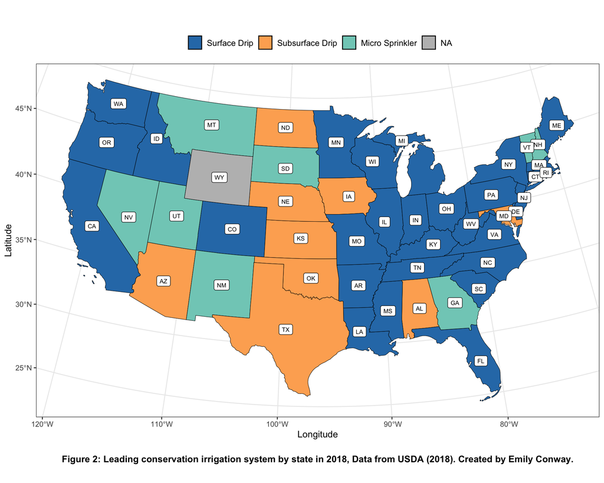

```r
ggplot() +                                                                       # create ggplot
  geom_sf(data = total_conserv, mapping = aes(fill = lead), col = "black", size = 1) + # create sf visualization, data from total_consev, fill state by lead, set color & size of map
  geom_sf_label(data = total_conserv, mapping = aes(label = postal), size = 2.5) + # create map labels, data from total_conserv, labels from postal column
  labs(x = "Longitude", y = "Latitude",                                          # set x and y axis labels
       caption = "Figure 2: Leading conservation irrigation system by state in 2018, Data from USDA (2018). Created by Emily Conway.", # set plot caption
       fill = "") +                                                              # remove legend title
  theme_bw() +                                                                   # set plot theme
  theme(plot.caption = element_text(hjust = 0.5, vjust = -5, color = "black", face = "bold", size = 11), # plot caption settings (horizontal adjust, color, bold)
        axis.title.x = element_text(color = "black", size = 11),                 # x axis title settings
        axis.title.y = element_text(color = "black", size = 11),                 # y axis title settings
        legend.text = element_text(color = "black", size = 10),                  # legend text settings
        legend.position = "top") +                                               # move legend position to top of plot
  scale_fill_manual(limits = c("surface_drip", "sub_drip", "micro_sprinkler", "NA"), # reorder legend
                    labels = c("Surface Drip", "Subsurface Drip", "Micro Sprinkler", "NA"), # rename and capitalize sector labels in legend
                    values = c("#2c7bb6", "#fdae61", "#80cdc1", "#bdbdbd"))      # set Color Brewer HEX values for each sector's color fill
```

**Q3: What five new functions did you implement to support visualization of the data? Explain what each of them does** I did not use any new functions in my ggplot code to produce Figure 2.

#### Step #7: Organize data for Plot 3: Top 10 conservation irrigation states in the U.S. in 2018

```r
# create df for top 10 states for conservation irrigation in 2018
conserv_top <- total_conserv |>                                                  # data from total_conserv
               select(postal, total) |>                                          # select columns of interest
               arrange(desc(total)) |>                                           # arrange rows by descending total values
               slice(1:10) |>                                                    # slice top 10 rows
               mutate(ranking = c("#1", "#2", "#3", "#4", "#5", "#6", "#7", "#8", "#9", "#10"))
```

#### Step #8: Plot 3: Top 10 conservation irrigation states in the U.S. in 2018

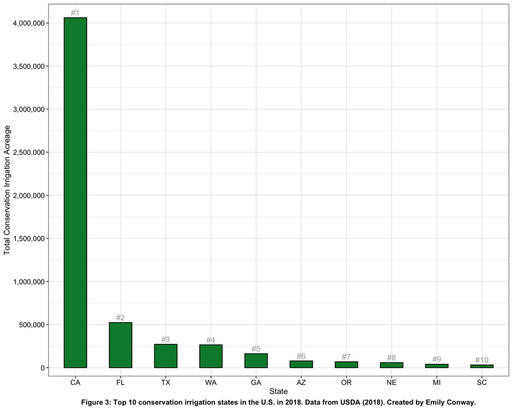

```r
ggplot() +                                                                       # create ggplot
  geom_col(data = conserv_top,                                                   # create colums, data from total_conserv
           aes(x = reorder(postal, -total), y = total),                          # set x & y data, reorder x axis by descending total values
           position = position_dodge2(width = 0.5), width = 0.5, color = "black", fill = "#008837") +  # set side by side columns (dodge), set spacing and column width, set column color
  geom_text(data = conserv_top, mapping = aes(x = postal, y = total, label = ranking), # add text for state rankings
            nudge_y = 60000, color = "darkgrey") +                                   # nudge text to avoid overlapping, text color
  labs(caption = "Figure 3: Top 10 conservation irrigation states in the U.S. in 2018. Data from USDA (2018). Created by Emily Conway.", # set plot caption
       x = "State", y = "Total Conservation Irrigation Acreage",                       # set x & y axis labels
       fill = "") +                                                              # remove legend title
  theme_bw() +                                                                   # set plot theme
  theme(plot.caption = element_text(hjust = 0.5, color = "black", face = "bold", size = 10),  # caption settings
        axis.text.x = element_text(color = "black", size = 10),                  # x axis text settings
        axis.text.y = element_text(color = "black", size = 10)) +                # y axis text settings
  scale_y_continuous(breaks = scales::breaks_extended(n = 8),                    # set pretty breaks for y axis
                     labels = scales::comma,                                     # separate axis value labels with commas
                     expand = c(0,100000))                                       # expand to close gaps between x & y axis AND make room for #1 ranking label
```

**Q1: What is the take home message of this figure?** Figure 3 displays the top ten states in the U.S. for conservation irrigation in 2018 as well as their relative acreage of total conservation irrigation installed. The figure shows that the top ten states are distributed across the United States. California has a significantly greater acreage of total conservation irrigation installed in 2018 than the other nine top states.

**Q2: What is most (or least) surprising?** It is not surprising that California has a much greater amount of conservation irrigation installed in 2018 compared to the other nine top U.S. states. This is because California is both a leader in agriculture and environmental policy. California likely has more funding and resources available to implement conservation irrigation throughout the state. When considering Figures 1 and 2, California has a large amount of drip irrigation, which is consistently the largest conservation irrigation system type installed in the U.S. However, I am surprised that Florida and Texas rank second and third to California since Florida is not a particularly large agricultural state, and they are historically conservative when it comes to environmental policy.

**Q3: What five new functions did you implement to support visualization of the data? Explain what each of them does** geom_text() - This function allows labeling of plots without a background. I used this function to label the ranking of each state in conservation irrigation. position_dodge2() - This function is used within the position argument in geom_col. This function works without having to group variables by layer. breaks_extended() - This function is an extended breaks algorithm for numerical axes which allowed me to set the breaks in y axis values.